# ZierHW4

Question 17. Model 4 seems to make sense because it was consistent throughout and it has the variables we care the most about because they are the most relevant to our question: whether or not a student graduated and percentage of students taking the exam.

Question 18.

```r
summary(mod.best)
```

```
##
## Call:
## lm(formula = sat.mathandverbal ~ percent.taking + percent.no.hs,
##     data = educ.sub)
##
## Residuals:
##    Min     1Q Median     3Q    Max
## -63.25 -21.66   5.12  20.85  61.14
##
## Coefficients:
##                 Estimate Std. Error t value Pr(>|t|)
## (Intercept)    1204.7760    20.1086  59.913  < 2e-16 ***
## percent.taking   -2.3443     0.1620 -14.474  < 2e-16 ***
## percent.no.hs    -2.5404     0.7613  -3.337  0.00164 **
## ---
## Signif. codes:  0 '***' 0.001 '**' 0.01 '*' 0.05 '.' 0.1 ' ' 1
##
## Residual standard error: 29.86 on 48 degrees of freedom
## Multiple R-squared:  0.8153, Adjusted R-squared:  0.8076
## F-statistic: 105.9 on 2 and 48 DF,  p-value: < 2.2e-16
```

We can say with 99.9% confidence that there is a negative correlation between percentage of students who take the SAT and the average SAT score. For every one percent increase in amount of students taking the exam the average score will drop by 2.34 points. Furthermore, we can say with 99% confidence that there is a negative correlation between percentage of students without a high school diploma and the average SAT scores in the state. When the percentage of students without a high school diploma increases by one there is a 2.54 decrease in the average SAT score.

Problem 3 library(car) data(“Angell”)

Question 19

```r
modl = lm(moral~hetero+mobility,data = Angell)
```

Question 20.

```r
library(texreg)
screenreg(modl)
```

```
##
## ======================
##              Model 1
## ----------------------
## (Intercept)  19.94 ***
##              (1.19)
## hetero       -0.11 ***
##              (0.02)
## mobility     -0.19 ***
##              (0.04)
## ----------------------
## R^2           0.62
## Adj. R^2      0.61
## Num. obs.    43
## RMSE          2.24
## ======================
## *** p < 0.001, ** p < 0.01, * p < 0.05
```

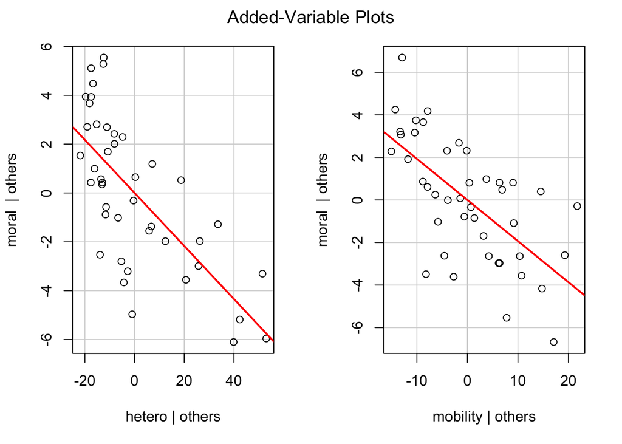

```r
#Heterogeneity and mobility are both negatively realted to moral integration. If you increase heterogeneity by one unit than moral integration wil decrease by 0.11 unitls. Increasing mobility by one unit results in a reduction of moral integration by 0.19 units. These relationships are statistically significant at the critical value of .001
avPlots(modl)
```

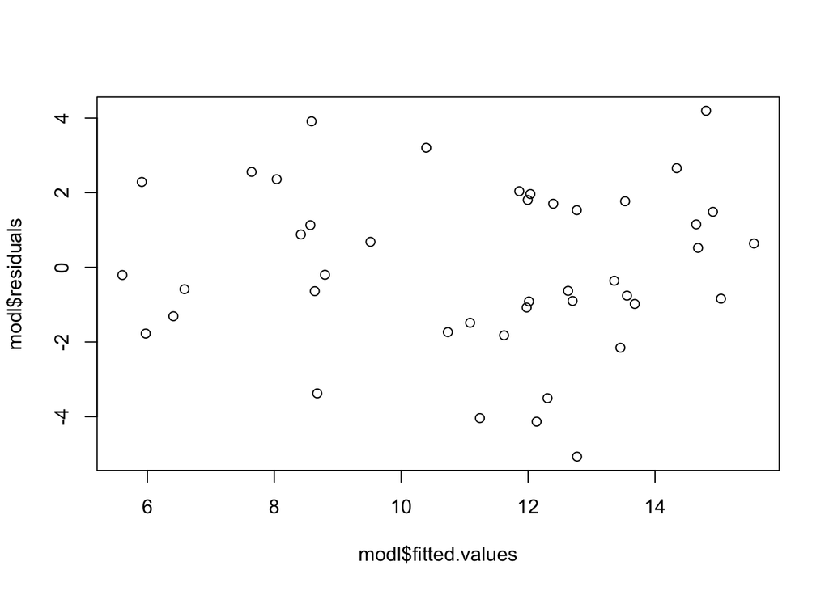

```r
plot(modl$residuals~modl$fitted.values)
```

BONUS I legitimately have no idea how to do this. I looked at your example in the key, though. Still a bit confused and not going to pretend I thought of any of that on my own for credit. Maybe we can go over it in class?